# PharmaSafe: Comprehensive Analysis of Drug Safety and Quality

This EDA made with training purposes by Natalia Lappalainen 12/2023 - 01/2024

Sources:

- https://www.kaggle.com/datasets/shudhanshusingh/250k-medicines-usage-side-effects-and-substitutes?resource=download
- ChatGPT
- Google
- school materials

Used techniques:

- Exploring and Visualisation
- Logistic Regression
- Decision Tree
- Assosiation analysis
- Clustering

### About Dataset

This dataset contains comprehensive information on over 248,000 medical drugs from all manufacturers available worldwide. The data includes details such as drug names, active ingredients, therapeutic uses, dosage, side effects, and substitutes. The dataset aims to provide a useful resource for medical researchers, healthcare professionals, and drug manufacturers.

The dataset contains the following information for each drug:

1. Drug name
2. dverse reactions and side effects
3. Drug interactions
4. Drug class
5. Substitute drugs
6. Active ingredients [Available in previous dataset published by us. Link added Below]

Dataset Related Info.:

Substitute : It indicates that whatever is the name of the medicine, if the consumer want's to know alternative medicine that have same compositions but manufactured by different manufacturers. So we have provided 5 substitutes for each drug/medicine.

Therapeutic Class : It is a way of classifying medical drugs according to their functions. Each therapeutic class is a group of similar medications classified together because they are intended to treat the same medical conditions. for eg.: Respiratory is one of the class, so all medication treating this illness comes under the same class.

Action Class : It is the way of classifying medications based on actions they perform such as "H2 Receptor Blocker" It Block H2 receptors in parietal cells of the stomach → decrease gastric acid secretion. So drugs with similar action are grouped under "H2 Receptor Blocker".

Chemical Class : As name suggests, it is grouping based on chemical compound used.

Habit Forming : It is classified as YES or NO. It is defined as the process of forming a habit, referring generally to psychological dependence on the continued use of a drug to maintain a sense of well-being, which can result in drug addiction. If there are chances of drug addiction, then it is set to YES otherwise NO.

FOR MAC:

- python3 -m venv env
- source env/bin/activate

FOR Windows:

- python -m venv env
- env\Scripts\activate

```python
# pip freeze > requirements.txt -> remember to update during the project to add additional libraries and modules if installed!

# import necessary libraries and modules
# pip install seaborn
import seaborn as sns
import pandas as pd
import numpy as np
import matplotlib.pyplot as plt

# remove warnings
import warnings
warnings.filterwarnings('ignore')
```

## Exploring and Visualisation

```python
# import and inspect the data
drugs = pd.read_csv('medicine_dataset.csv')
drugs.info()
```

```
<class 'pandas.core.frame.DataFrame'>
RangeIndex: 248218 entries, 0 to 248217
Data columns (total 58 columns):
 #   Column             Non-Null Count   Dtype
---  ------             --------------   -----
 0   id                 248218 non-null  int64
 1   name               248218 non-null  object
 2   substitute0        238621 non-null  object
 3   substitute1        233867 non-null  object
 4   substitute2        230233 non-null  object
 5   substitute3        226856 non-null  object
 6   substitute4        223962 non-null  object
 7   sideEffect0        248218 non-null  object
 8   sideEffect1        238416 non-null  object
 9   sideEffect2        229500 non-null  object
```

[output cut: 50 more lines]

```python
# check missing values
nan_count = drugs.isna().sum().sum()
if nan_count <= 0:
    print('No missing values')
else:
    print('Number of missing values:', nan_count)

# check duplicates
dups = drugs.duplicated()
dups = dups.sum()
if dups <= 0:
    print('No duplicates')
else:
    print('Number of duplicates:', dups)

# dataset shape
display(drugs.head(3))
print('This dataset contains',drugs.shape[0],'rows and', drugs.shape[1],'columns')
```

```
Number of missing values: 10002467
No duplicates
```

|  | id | name | substitute0 | substitute1 | substitute2 | substitute3 | substitute4 | sideEffect0 | sideEffect1 | sideEffect2 | ... | sideEffect41 | use0 | use1 | use2 | use3 | use4 | Chemical Class | Habit Forming | Therapeutic Class | Action Class |
| --- | --- | --- | --- | --- | --- | --- | --- | --- | --- | --- | --- | --- | --- | --- | --- | --- | --- | --- | --- | --- | --- |
| 0 | 1 | augmentin 625 duo tablet | Penciclav 500 mg/125 mg Tablet | Moxikind-CV 625 Tablet | Moxiforce-CV 625 Tablet | Fightox 625 Tablet | Novamox CV 625mg Tablet | Vomiting | Nausea | Diarrhea | ... | NaN | Treatment of Bacterial infections | NaN | NaN | NaN | NaN | NaN | No | ANTI INFECTIVES | NaN |
| 1 | 2 | azithral 500 tablet | Zithrocare 500mg Tablet | Azax 500 Tablet | Zady 500 Tablet | Cazithro 500mg Tablet | Trulimax 500mg Tablet | Vomiting | Nausea | Abdominal pain | ... | NaN | Treatment of Bacterial infections | NaN | NaN | NaN | NaN | Macrolides | No | ANTI INFECTIVES | Macrolides |
| 2 | 3 | ascoril ls syrup | Solvin LS Syrup | Ambrodil-LX Syrup | Zerotuss XP Syrup | Capex LS Syrup | Broxum LS Syrup | Nausea | Vomiting | Diarrhea | ... | NaN | Treatment of Cough with mucus | NaN | NaN | NaN | NaN | NaN | No | RESPIRATORY | NaN |

3 rows × 58 columns

```
This dataset contains 248218 rows and 58 columns
```

```python
# count occurrences of each unique drug name
print(drugs['name'].value_counts())
```

```
name
ns 0.9% infusion                     13
meditrax s 1000mg/500mg injection     8
modace 100mg/500mg tablet             6
mucohelp 1gm injection                6
matchfix-cv 200mg/125mg tablet        6
                                     ..
etoxiflam 120mg tablet                1
etocrax 90mg tablet                   1
edikacin 500mg injection              1
eurotam 0.40mg tablet                 1
zyvocol 1% dusting powder             1
Name: count, Length: 222825, dtype: int64
```

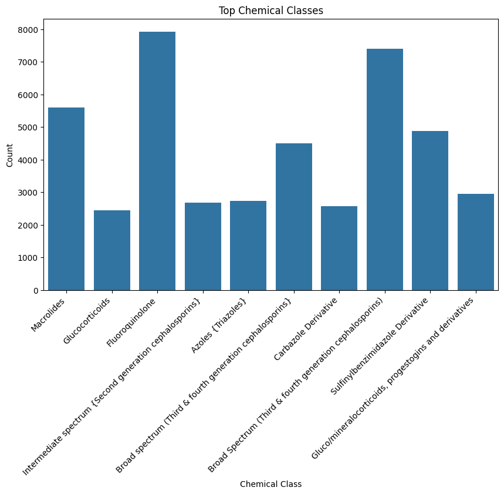

```python
# show top 10 classes in Chemical Class
top_classes = drugs['Chemical Class'].value_counts().nlargest(10).index
plt.figure(figsize=(10, 6))
sns.countplot(x='Chemical Class', data=drugs[drugs['Chemical Class'].isin(top_classes)])
plt.title('Top Chemical Classes')
plt.xlabel('Chemical Class')
plt.ylabel('Count')
plt.xticks(rotation=45, ha='right')
plt.show()
```

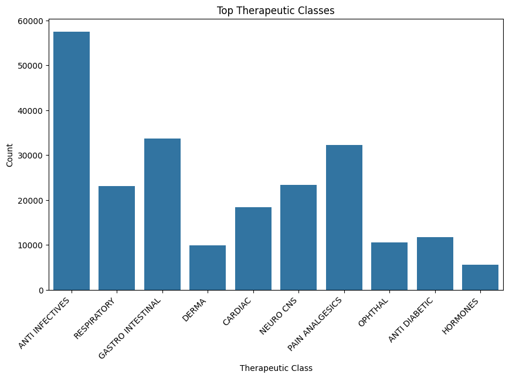

```python
# show top 10 classes in Therapeutic Class
top_classes = drugs['Therapeutic Class'].value_counts().nlargest(10).index
plt.figure(figsize=(10, 6))
sns.countplot(x='Therapeutic Class', data=drugs[drugs['Therapeutic Class'].isin(top_classes)])
plt.title('Top Therapeutic Classes')
plt.xlabel('Therapeutic Class')
plt.ylabel('Count')
plt.xticks(rotation=45, ha='right')
plt.show()
```

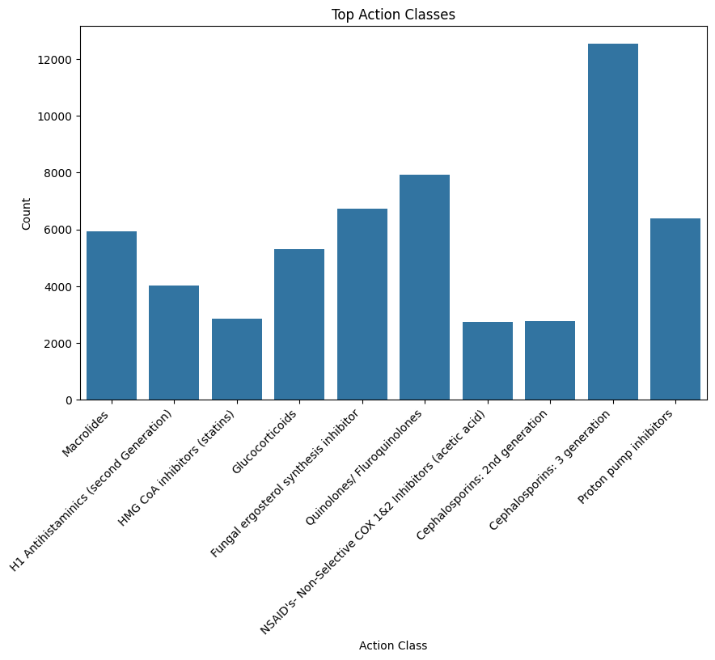

```python
# show top 10 classes in Action Class
top_classes = drugs['Action Class'].value_counts().nlargest(10).index
plt.figure(figsize=(10, 6))
sns.countplot(x='Action Class', data=drugs[drugs['Action Class'].isin(top_classes)])
plt.title('Top Action Classes')
plt.xlabel('Action Class')
plt.ylabel('Count')
plt.xticks(rotation=45, ha='right')
plt.show()
```

### Exploration of Side Effects

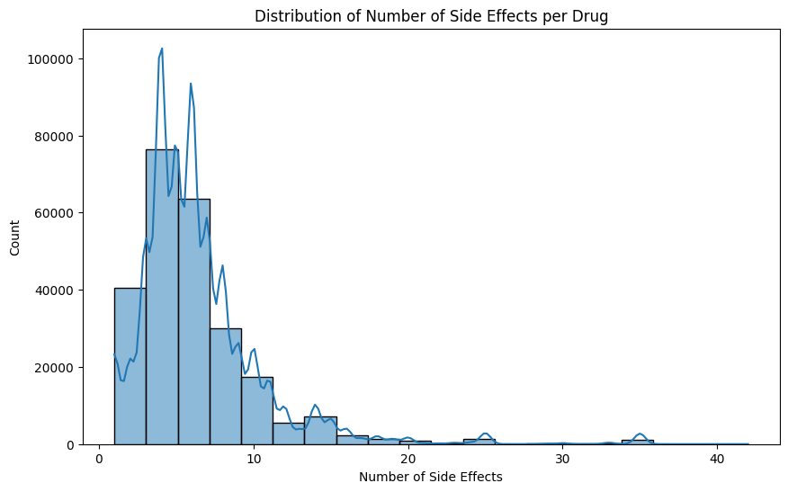

```python
# count the number of side effects for each drug
side_effects_count = drugs.filter(like='sideEffect').count(axis=1)

# visualize the distribution
plt.figure(figsize=(10, 6))
sns.histplot(side_effects_count, bins=20, kde=True)
plt.title('Distribution of Number of Side Effects per Drug')
plt.xlabel('Number of Side Effects')
plt.ylabel('Count')
plt.show()
```

```
<function matplotlib.pyplot.xticks(ticks: 'ArrayLike | None' = None, labels: 'Sequence[str] | None' = None, *, minor: 'bool' = False, **kwargs) -> 'tuple[list[Tick] | np.ndarray, list[Text]]'>
```

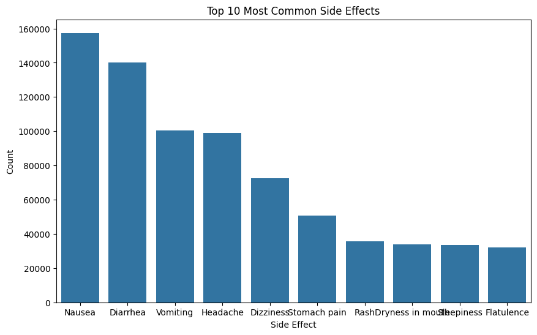

```python
# count occurrences of each side effect
all_side_effects = drugs.filter(like='sideEffect').stack().value_counts()

# visualize the top 10 side effects
plt.figure(figsize=(10, 6))
sns.barplot(x=all_side_effects.head(10).index, y=all_side_effects.head(10).values)
plt.title('Top 10 Most Common Side Effects')
plt.xlabel('Side Effect')
plt.ylabel('Count')
plt.xticks
```

```python
# calculate mean and median of side effects count
mean_side_effects = side_effects_count.mean()
median_side_effects = side_effects_count.median()

print(f'Mean number of side effects per drug: {mean_side_effects:.2f}')
print(f'Median number of side effects per drug: {median_side_effects}')
```

```
Mean number of side effects per drug: 6.49
Median number of side effects per drug: 6.0
```

In this step, I aim to simplify the dataset by aggregating columns related to substitutes, side effects, and usage. This will enhance readability and make the dataset more manageable for subsequent analyses.

```python
# creating the aggregated dataset
aggregated_drugs = drugs.copy()

# combining columns
aggregated_drugs['Substitutes'] = drugs.filter(like='substitute').apply(lambda x: ', '.join(x.dropna()), axis=1)
aggregated_drugs['Side Effects'] = drugs.filter(like='sideEffect').apply(lambda x: ', '.join(x.dropna()), axis=1)
aggregated_drugs['Usage'] = drugs.filter(like='use').apply(lambda x: ', '.join(x.dropna()), axis=1)

# removing original needless columns
aggregated_drugs = aggregated_drugs.drop(columns=drugs.filter(like='substitute').columns)
aggregated_drugs = aggregated_drugs.drop(columns=drugs.filter(like='sideEffect').columns)
aggregated_drugs = aggregated_drugs.drop(columns=drugs.filter(like='use').columns)

aggregated_drugs.head(3)
```

|  | id | name | Chemical Class | Habit Forming | Therapeutic Class | Action Class | Substitutes | Side Effects | Usage |
| --- | --- | --- | --- | --- | --- | --- | --- | --- | --- |
| 0 | 1 | augmentin 625 duo tablet | NaN | No | ANTI INFECTIVES | NaN | Penciclav 500 mg/125 mg Tablet, Moxikind-CV 62... | Vomiting, Nausea, Diarrhea | Treatment of Bacterial infections |
| 1 | 2 | azithral 500 tablet | Macrolides | No | ANTI INFECTIVES | Macrolides | Zithrocare 500mg Tablet, Azax 500 Tablet, Zady... | Vomiting, Nausea, Abdominal pain, Diarrhea | Treatment of Bacterial infections |
| 2 | 3 | ascoril ls syrup | NaN | No | RESPIRATORY | NaN | Solvin LS Syrup, Ambrodil-LX Syrup, Zerotuss X... | Nausea, Vomiting, Diarrhea, Upset stomach, Sto... | Treatment of Cough with mucus |

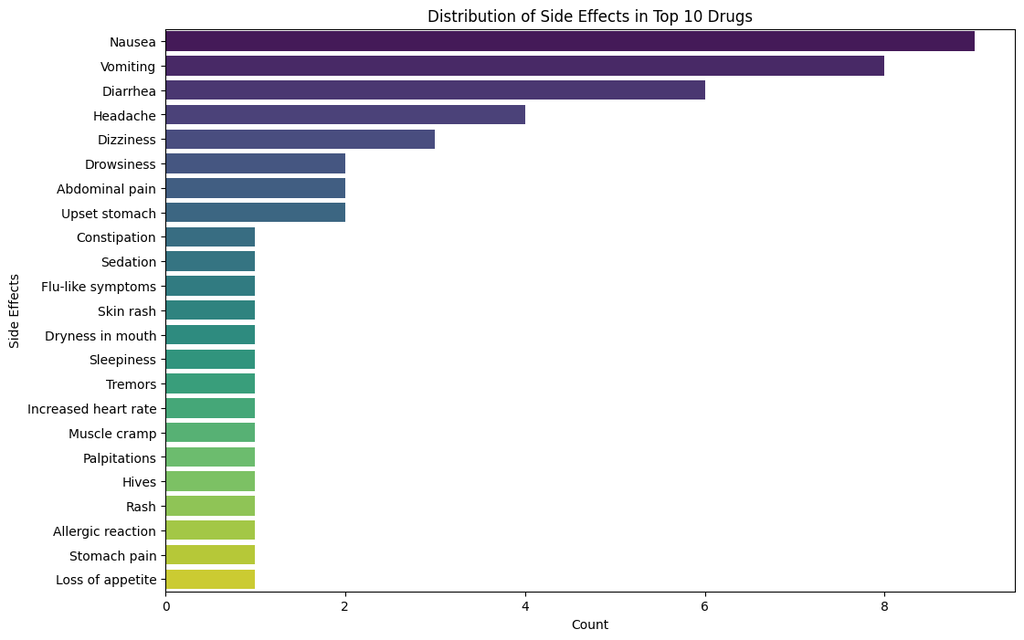

```python
# first 10 drugs from the aggregated dataset for demonstration
subset_aggregated = aggregated_drugs[['name', 'Side Effects']].head(10)

# melt the DataFrame into a long format for easier plotting
melted_data_aggregated = subset_aggregated['Side Effects'].str.split(', ', expand=True).stack().reset_index(level=0).set_index('level_0').rename(columns={0: 'Side Effect'})

# create a histogram of side effects
plt.figure(figsize=(12, 8))
sns.countplot(y=melted_data_aggregated['Side Effect'], order=melted_data_aggregated['Side Effect'].value_counts().index, palette='viridis')
plt.title('Distribution of Side Effects in Top 10 Drugs')
plt.xlabel('Count')
plt.ylabel('Side Effects')
plt.show()
```

### Classification of Drugs Based on Safety

### Data Preprocessing Decision

As this is quite a massive dataset, containing 248,218 rows and 58 columns, optimizing the data for efficient processing is crucial for effective analysis. For the purpose of this training project, a decision has been made to enhance the efficiency of data processing. To achieve this, rows containing drugs with less than 1000 occurrences in the "Usage" column have been removed. This choice is aimed at streamlining the dataset and expediting the analysis, considering the specific goals and scope of the project.

```python
# analysis of values in the "Usage" column
usage_counts = aggregated_drugs['Usage'].value_counts()

# identification of rare values (less than 1000 occurrences)
rare_usage_values = usage_counts[usage_counts < 1000].index

# removal of rows with rare "Usage" values
aggregated_drugs_filtered = aggregated_drugs[~aggregated_drugs['Usage'].isin(rare_usage_values)]
```

### Creating "Safety Level" scale, based on the insights gathered from the side effect analysis to determine the safety of each drug

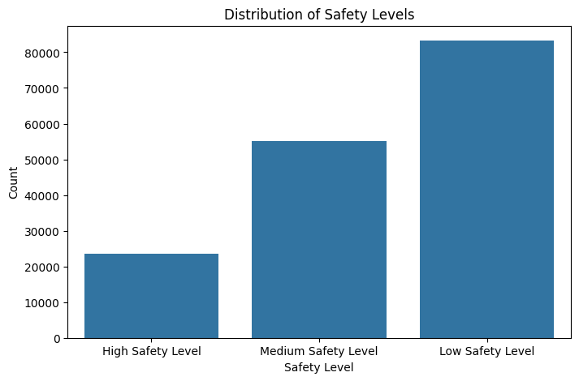

```python
# assigns a safety level to a drug based on the count of side effects
def assign_safety_level(count):
    mean_threshold = 5
    median_threshold = 3

    if count <= median_threshold:
        return 'High Safety Level'
    elif count <= mean_threshold:
        return 'Medium Safety Level'
    else:
        return 'Low Safety Level'

# apply the function to create the 'Safety Level' column
aggregated_drugs_filtered['Safety Level'] = side_effects_count.apply(assign_safety_level)

# display the distribution of safety levels
plt.figure(figsize=(8, 5))
sns.countplot(x='Safety Level', data=aggregated_drugs_filtered, order=['High Safety Level', 'Medium Safety Level', 'Low Safety Level'])
plt.title('Distribution of Safety Levels')
plt.xlabel('Safety Level')
plt.ylabel('Count')
plt.show()
```

## Logistic Regression with Cross-validation

```python
# pip install skicit-learn
from sklearn.model_selection import train_test_split
from sklearn.linear_model import LogisticRegression
from sklearn.metrics import accuracy_score, classification_report
```

```python
# create dedicated DataFrame for logistic regression analysis to focus on relevant features and set name for index
log_reg_drugs = aggregated_drugs_filtered.set_index('name')
log_reg_drugs

# convert categorical strings to numeric values for modeling
log_reg_drugs['Habit Forming'].replace(['No','Yes'], [0,1], inplace=True)
log_reg_drugs['Side Effects'] = log_reg_drugs['Side Effects'].apply(lambda x: 0 if pd.isna(x) else len(str(x).split(',')))

# map the categorical 'Safety Level' to numeric values for logistic regression
log_reg_drugs['Safety Level'] = log_reg_drugs['Safety Level'].map({
    'High Safety Level': 1,
    'Medium Safety Level': 2,
    'Low Safety Level': 3
})

# drop unneccessary columns that are not considered in the logistic regression model
log_reg_drugs.drop(['id','Chemical Class','Therapeutic Class','Action Class','Substitutes','Usage'], axis=1, inplace=True)

log_reg_drugs
```

| name | Habit Forming | Side Effects | Safety Level |
| --- | --- | --- | --- |
| augmentin 625 duo tablet | 0 | 3 | 1 |
| azithral 500 tablet | 0 | 4 | 2 |
| ascoril ls syrup | 0 | 14 | 3 |
| avil 25 tablet | 0 | 2 | 1 |
| amoxyclav 625 tablet | 0 | 3 | 1 |
| ... | ... | ... | ... |
| zunix 50mg dry syrup | 0 | 6 | 3 |
| zestrain 100mg/325mg/250mg tablet mr | 0 | 8 | 3 |
| zoxinace 200mg tablet sr | 0 | 5 | 2 |
| zi fast 500mg injection | 0 | 7 | 2 |
| zyvocol 1% dusting powder | 0 | 4 | 2 |

161838 rows × 3 columns

```python
# creating a feature matrix X and target variable y
X = log_reg_drugs[['Habit Forming', 'Side Effects']]
y = log_reg_drugs['Safety Level']

# split the dataset into training and testing sets
X_train, X_test, y_train, y_test = train_test_split(X, y, test_size=0.2, random_state=42, stratify=y)
print('Training data: ', X_train.shape, y_train.shape)
print('Testing data: ', X_test.shape, y_test.shape)
```

```
Training data:  (129470, 2) (129470,)
Testing data:  (32368, 2) (32368,)
```

```python
# initialize and train a logistic regression model
log_reg_model = LogisticRegression()
log_reg_model.fit(X_train, y_train)

# make predictions on the test set
y_pred = log_reg_model.predict(X_test)

# evaluate the model's performance
accuracy = accuracy_score(y_test, y_pred)
classification_report_result = classification_report(y_test, y_pred)

# output the coefficients and intercept of the logistic regression model
print("Coefficients: ",log_reg_model.coef_)
print("Intercept: ", log_reg_model.intercept_)

# display accuracy and classification report
print(f'Accuracy: {accuracy:.2f}')
print('Classification Report:')
print(classification_report_result)
```

```
Coefficients:  [[-0.22157727 -5.8945529 ]
 [ 0.11932235  0.87844894]
 [ 0.10225492  5.01610396]]
Intercept:  [ 24.147498   -0.4960653 -23.6514327]
Accuracy: 0.97
Classification Report:
              precision    recall  f1-score   support

           1       1.00      0.89      0.94      4690
           2       0.95      0.95      0.95     11024
           3       0.97      1.00      0.98     16654

    accuracy                           0.97     32368
   macro avg       0.97      0.95      0.96     32368
weighted avg       0.97      0.97      0.97     32368
```

The logistic regression model demonstrates high accuracy (97%) in predicting safety levels in out project. Precision, recall, and F1-score metrics are strong across all safety classes, indicating robust performance. The coefficients and intercept suggest meaningful features contribute to the predictions. Overall, the model is effective in its classification task.

```python
# cross-validation
from sklearn.model_selection import cross_val_score

# number of folds used: 3, 5, 10
k3 = 3
scores = cross_val_score(estimator=log_reg_model,
                        X=X_test,
                        y=y_test,
                        scoring="accuracy",
                        cv=k3)
print("Accuracies from %d individual folds:" % k3)
print(scores)
print("Accuracy calculated using %d-fold cross validation = %.3f" % (k3, scores.mean()))
print()
k5 = 5
scores = cross_val_score(estimator=log_reg_model,
                        X=X_test,
                        y=y_test,
                        scoring="accuracy",
                        cv=k5)
print("Accuracies from %d individual folds:" % k3)
print(scores)
print("Accuracy calculated using %d-fold cross validation = %.3f" % (k3, scores.mean()))
print()
k10 = 10
scores = cross_val_score(estimator=log_reg_model,
                        X=X_test,
                        y=y_test,
                        scoring="accuracy",
                        cv=k10)
print("Accuracies from %d individual folds:" % k10)
print(scores)
print("Accuracy calculated using %d-fold cross validation = %.3f" % (k10, scores.mean()))
```

```
Accuracies from 3 individual folds:
[0.96404078 0.965057   0.96830105]
Accuracy calculated using 3-fold cross validation = 0.966

Accuracies from 3 individual folds:
[0.96339203 0.96261971 0.96586345 0.97111077 0.96601267]
Accuracy calculated using 3-fold cross validation = 0.966

Accuracies from 10 individual folds:
[0.96107507 0.96570899 0.96725363 0.95798579 0.96632685 0.96540006
 0.97188755 0.97034291 0.96260816 0.96940667]
Accuracy calculated using 10-fold cross validation = 0.966
```

The model's performance remains consistent across different fold configurations, indicating stability and reliability in its predictive capabilities.

```python
# logarithmic loss
from sklearn.metrics import log_loss

# logloss for test data
logloss_test = log_loss(y_test, log_reg_model.predict_proba(X_test))
print(logloss_test)

# logloss for entire data
logloss = log_loss(y, log_reg_model.predict_proba(X))
print(logloss)
```

```
0.17692089685598494
0.18061695531699198
```

The log loss values for the test data (0.177) and the entire dataset (0.181) are in close proximity, indicating that the model's performance on the test set aligns well with its overall performance on the complete dataset. The similarity in log loss values suggests consistent predictive accuracy across different subsets of the data.

```python
# confusion matrix
from sklearn.metrics import confusion_matrix

cm_percent = confusion_matrix(y_test, y_pred, normalize='true').round(2)
cm_numeric = confusion_matrix(y_test, y_pred).round(2)
print("Confusion matrix in percent:\n",cm_percent)
print("Confusion matrix in numeric:\n",cm_numeric)
```

```
Confusion matrix in percent:
 [[0.89 0.11 0.  ]
 [0.   0.95 0.05]
 [0.   0.   1.  ]]
Confusion matrix in numeric:
 [[ 4175   515     0]
 [    0 10432   592]
 [    0     0 16654]]
```

In percent:

- 89% of the true class 1 samples were correctly predicted as class 1, 11% were misclassified as class 2.
- 95% of the true class 2 samples were correctly predicted as class 2, 5% were misclassified as class 3.
- 100% of the true class 3 samples were correctly predicted as class 3.

In numeric:

- 4175 samples were correctly predicted as class 1, 515 were misclassified as class 2, and 0 were misclassified as class 3.
- 10432 samples were correctly predicted as class 2, 0 were misclassified as class 1, and 592 were misclassified as class 3.
- 16654 samples were correctly predicted as class 3, and 0 were misclassified as class 1 or class 2.

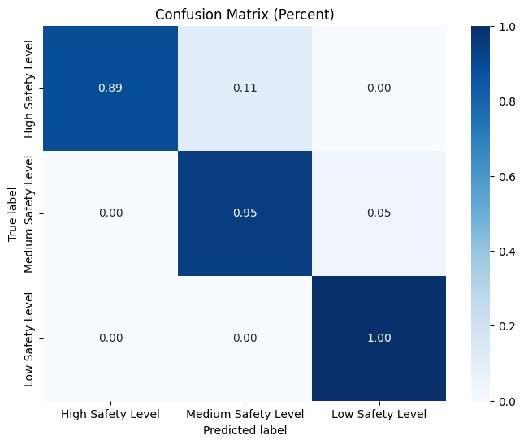

```python
# compute confusion matrix
cm = confusion_matrix(y_test, y_pred)

# normalize confusion matrix
cm_percent = cm.astype('float') / cm.sum(axis=1)[:, np.newaxis]

# define class labels
class_labels = ['High Safety Level', 'Medium Safety Level', 'Low Safety Level']

# create a heatmap
plt.figure(figsize=(8, 6))
sns.heatmap(cm_percent, annot=True, fmt=".2f", cmap="Blues", xticklabels=class_labels, yticklabels=class_labels)
plt.title('Confusion Matrix (Percent)')
plt.xlabel('Predicted label')
plt.ylabel('True label')
plt.show()
```

The confusion matrix visualizations and results indicate that the logistic regression model performs well in predicting the safety levels (High, Medium, Low) for our project, with high accuracy and minimal confusion between classes.

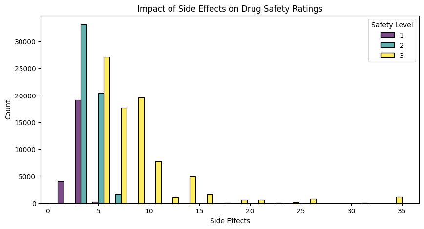

```python
# set the size of the plot
plt.figure(figsize=(10, 5))

sns.histplot(
    data=log_reg_drugs,
    x="Side Effects",
    hue="Safety Level",
    multiple="dodge",
    bins=20,
    alpha=0.7,
    palette='viridis'
).set_title("Impact of Side Effects on Drug Safety Ratings")

plt.show()
```

```python
from scipy import stats

# remove outliers
drugs_no_outliers = log_reg_drugs.copy()
drugs_no_outliers.astype(float)

# identify and replace outliers with NaN
colns = drugs_no_outliers.columns.values.tolist()
for each in colns:
    drugs_no_outliers.loc[np.abs(stats.zscore(drugs_no_outliers[each])) > 3, each] = np.NaN
```

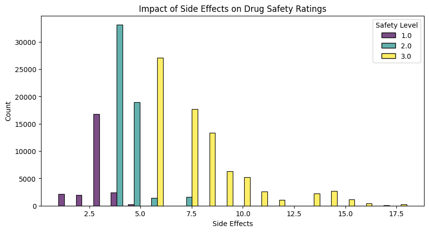

```python
# reset the index before creating the histogram
drugs_no_outliers.reset_index(drop=True, inplace=True)

# set the size of the plot
plt.figure(figsize=(10, 5))

sns.histplot(
    data=drugs_no_outliers,
    x="Side Effects",
    hue="Safety Level",
    multiple="dodge",
    bins=20,
    alpha=0.7,
    palette='viridis'
).set_title("Impact of Side Effects on Drug Safety Ratings")

plt.show()
```

## Decision Tree

```python
# create own df for Decision Tree analysis and set id for index
dec_tree_drugs = aggregated_drugs_filtered.set_index('name')
dec_tree_drugs

# convert strings to numeric
dec_tree_drugs['Habit Forming'].replace(['No','Yes'], [0,1], inplace=True)
dec_tree_drugs['Side Effects'] = dec_tree_drugs['Side Effects'].apply(lambda x: 0 if pd.isna(x) else len(str(x).split(',')))

# drop unneccessary columns
dec_tree_drugs.drop(['id','Chemical Class','Therapeutic Class','Action Class','Substitutes','Usage'], axis=1, inplace=True)

dec_tree_drugs
```

| name | Habit Forming | Side Effects | Safety Level |
| --- | --- | --- | --- |
| augmentin 625 duo tablet | 0 | 3 | High Safety Level |
| azithral 500 tablet | 0 | 4 | Medium Safety Level |
| ascoril ls syrup | 0 | 14 | Low Safety Level |
| avil 25 tablet | 0 | 2 | High Safety Level |
| amoxyclav 625 tablet | 0 | 3 | High Safety Level |
| ... | ... | ... | ... |
| zunix 50mg dry syrup | 0 | 6 | Low Safety Level |
| zestrain 100mg/325mg/250mg tablet mr | 0 | 8 | Low Safety Level |
| zoxinace 200mg tablet sr | 0 | 5 | Medium Safety Level |
| zi fast 500mg injection | 0 | 7 | Medium Safety Level |
| zyvocol 1% dusting powder | 0 | 4 | Medium Safety Level |

161838 rows × 3 columns

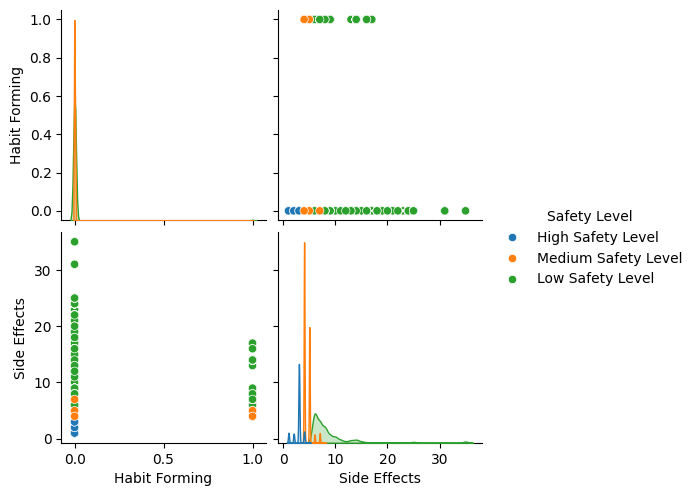

```python
sns.pairplot(dec_tree_drugs, hue='Safety Level')
```

```python
colnames = dec_tree_drugs.columns
colnames
```

```
Index(['Habit Forming', 'Side Effects', 'Safety Level'], dtype='object')
```

```python
X = dec_tree_drugs[['Habit Forming', 'Side Effects']]
Y_true = dec_tree_drugs['Safety Level']
```

```python
from sklearn import tree
```

```python
classifier = tree.DecisionTreeClassifier(max_depth=2)
classifier.fit(X,Y_true)
```

```
DecisionTreeClassifier(max_depth=2)
```

```python
print(tree.export_text(classifier))
```

```
|--- feature_1 <= 5.50
|   |--- feature_1 <= 3.50
|   |   |--- class: High Safety Level
|   |--- feature_1 >  3.50
|   |   |--- class: Medium Safety Level
|--- feature_1 >  5.50
|   |--- feature_1 <= 7.50
|   |   |--- class: Low Safety Level
|   |--- feature_1 >  7.50
|   |   |--- class: Low Safety Level
```

```python
# download Graphviz # https://graphviz.org/download/, unzip
# graphviz is tricky, for Mac try this: sudo port install graphviz
# or this if have Homebrew: brew install graphviz
# might requre: brew reinstall graphviz
# pip install graphviz
import graphviz
import os
from pathlib import Path
```

```python
os.environ['PATH'] += os.pathsep +str(Path('.').resolve() / Path('Graphviz/bin'))
```

```python
visu_data = tree.export_graphviz(classifier, out_file=None,
feature_names=colnames[:2],
class_names=['High Safety Level','Medium Safety Level', 'Low Safety Level'],
filled=True,
node_ids=True,
#proportion=True,
rounded=True,
special_characters=True)

graph = graphviz.Source(visu_data)

graph
```

[figure not shown]

```python
# initialize and train a decision tree model
from sklearn.tree import DecisionTreeClassifier
decision_tree_model = DecisionTreeClassifier(random_state=42)
decision_tree_model.fit(X_train, y_train)

# make predictions on the test set
y_pred = decision_tree_model.predict(X_test)

# Evaluate the decision tree model
accuracy = accuracy_score(y_test, y_pred)
classification_report_result = classification_report(y_test, y_pred)

print(f'Decision Tree Model Accuracy: {accuracy:.2f}')
print('Decision Tree Model Classification Report:')
print(classification_report_result)
```

```
Decision Tree Model Accuracy: 0.97
Decision Tree Model Classification Report:
              precision    recall  f1-score   support

           1       1.00      0.89      0.94      4690
           2       0.95      0.95      0.95     11024
           3       0.97      1.00      0.98     16654

    accuracy                           0.97     32368
   macro avg       0.97      0.95      0.96     32368
weighted avg       0.97      0.97      0.97     32368
```

```python
Y_pred = classifier.predict(X)

# confusion matrix
cm = confusion_matrix(Y_true, Y_pred)
print("Confusion matrix:\n",cm)

# accuracy
accuracy = accuracy_score(Y_true, Y_pred)
print("Accuracy calculated from the training set = %.3f" % (accuracy))

# create raport
print(classification_report(Y_true, Y_pred, target_names=['High Safety Level','Medium Safety Level', 'Low Safety Level']))
```

```
Confusion matrix:
 [[20855     0  2594]
 [    0 83267     0]
 [    0  2999 52123]]
Accuracy calculated from the training set = 0.965
                     precision    recall  f1-score   support

  High Safety Level       1.00      0.89      0.94     23449
Medium Safety Level       0.97      1.00      0.98     83267
   Low Safety Level       0.95      0.95      0.95     55122

           accuracy                           0.97    161838
          macro avg       0.97      0.94      0.96    161838
       weighted avg       0.97      0.97      0.97    161838
```

```
<sklearn.metrics._plot.confusion_matrix.ConfusionMatrixDisplay at 0x2cbd1f910>
```

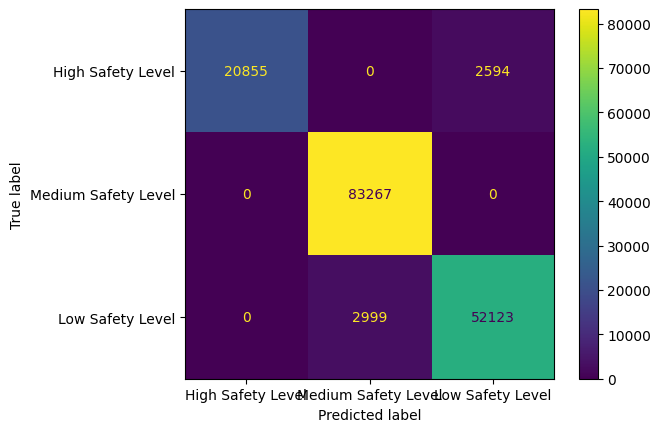

```python
# create heatmap
from sklearn.metrics import ConfusionMatrixDisplay

cm = confusion_matrix(Y_true, Y_pred)  #normalize='all'
cmd = ConfusionMatrixDisplay(cm, display_labels=['High Safety Level','Medium Safety Level', 'Low Safety Level'])
cmd.plot()
```

The decision tree model shows promising results with an accuracy of 96.5%. It performs well across different safety levels, achieving high precision and recall. The confusion matrix indicates that the model makes very few misclassifications. Overall, the decision tree model demonstrates strong predictive capabilities on the given dataset.

## Association Analysis

1. Apriori

```python
# pip install apyori
from apyori import apriori

# select the columns of interest
association_data = aggregated_drugs_filtered[['Habit Forming', 'Side Effects', 'Safety Level']]

# convert data to one-hot encoding
association_data = pd.get_dummies(association_data, drop_first=True)

# convert to transaction format
transactions = association_data.apply(lambda row: row[row == 1].index.tolist(), axis=1).tolist()

# apply Apriori algorithm
results = list(apriori(transactions, min_support=0.01, min_confidence=0.5))
```

```python
# extract metrics for association rules
data = []

# loop through Apriori results
for a in results:
    support = a.support
    items = a.items
    rules = a.ordered_statistics

    # loop through association rules
    for b in rules:
        lhs = b.items_base  # left-hand side
        rhs = b.items_add   # right-hand side
        conf = b.confidence
        lift = b.lift

        # append metrics to data list
        data.append([support, conf, lhs, rhs, lift])

# display the number of extracted metrics
len(data)
```

```
20
```

```python
# create DataFrame to store association rule metrics
columns = ["Support", "Confidence", "LHS", "RHS", "Lift"]
data1 = pd.DataFrame(data, columns=columns)
# display the first 10 rows of the association rule metrics DataFrame
data1.head(10)
```

|  | Support | Confidence | LHS | RHS | Lift |
| --- | --- | --- | --- | --- | --- |
| 0 | 0.514508 | 0.514508 | () | (Safety Level_Low Safety Level) | 1.000000 |
| 1 | 0.012611 | 1.000000 | (Side Effects_Diarrhea, Flatulence, Headache, ... | (Safety Level_Low Safety Level) | 1.943603 |
| 2 | 0.014823 | 1.000000 | (Side Effects_Diarrhea, Stomach pain, Dryness ... | (Safety Level_Low Safety Level) | 1.943603 |
| 3 | 0.018389 | 1.000000 | (Side Effects_Diarrhea, Stomach pain, Flatulen... | (Safety Level_Low Safety Level) | 1.943603 |
| 4 | 0.010690 | 1.000000 | (Side Effects_Dyspepsia, Abdominal pain, Indig... | (Safety Level_Low Safety Level) | 1.943603 |
| 5 | 0.013081 | 1.000000 | (Side Effects_Increased appetite, Weight gain,... | (Safety Level_Low Safety Level) | 1.943603 |
| 6 | 0.014830 | 1.000000 | (Side Effects_Nausea, Diarrhea, Dryness in mou... | (Safety Level_Low Safety Level) | 1.943603 |
| 7 | 0.012587 | 1.000000 | (Side Effects_Nausea, Vomiting, Dizziness, Hea... | (Safety Level_Low Safety Level) | 1.943603 |
| 8 | 0.020286 | 1.000000 | (Side Effects_Nausea, Vomiting, Stomach pain, ... | (Safety Level_Low Safety Level) | 1.943603 |
| 9 | 0.015596 | 1.000000 | (Side Effects_Nausea, Vomiting, Stomach pain/e... | (Safety Level_Low Safety Level) | 1.943603 |

```python
# retrieve the top 10 association rules based on Lift
data1.nlargest(n = 10, columns = 'Lift')
```

|  | Support | Confidence | LHS | RHS | Lift |
| --- | --- | --- | --- | --- | --- |
| 12 | 0.018568 | 1.0 | (Side Effects_Diarrhea, Increased liver enzyme... | (Safety Level_Medium Safety Level) | 2.935997 |
| 13 | 0.013489 | 1.0 | (Side Effects_Dizziness, Sleepiness, Tiredness... | (Safety Level_Medium Safety Level) | 2.935997 |
| 14 | 0.012037 | 1.0 | (Side Effects_Headache, Dizziness, Nausea, Con... | (Safety Level_Medium Safety Level) | 2.935997 |
| 15 | 0.018413 | 1.0 | (Side Effects_Hypoglycemia (low blood glucose ... | (Safety Level_Medium Safety Level) | 2.935997 |
| 16 | 0.015658 | 1.0 | (Side Effects_Nausea, Common cold, Cough, Blur... | (Safety Level_Medium Safety Level) | 2.935997 |
| 17 | 0.019408 | 1.0 | (Side Effects_Nausea, Stomach pain, Indigestio... | (Safety Level_Medium Safety Level) | 2.935997 |
| 18 | 0.011604 | 1.0 | (Side Effects_Nausea, Vomiting, Diarrhea, Incr... | (Safety Level_Medium Safety Level) | 2.935997 |
| 19 | 0.032224 | 1.0 | (Side Effects_Vomiting, Nausea, Abdominal pain... | (Safety Level_Medium Safety Level) | 2.935997 |
| 1 | 0.012611 | 1.0 | (Side Effects_Diarrhea, Flatulence, Headache, ... | (Safety Level_Low Safety Level) | 1.943603 |
| 2 | 0.014823 | 1.0 | (Side Effects_Diarrhea, Stomach pain, Dryness ... | (Safety Level_Low Safety Level) | 1.943603 |

The association rules extracted from the Apriori algorithm indicate strong relationships between specific side effects and certain safety levels. For example, the presence of side effects such as "Diarrhea," "Increased liver enzyme," and others is consistently associated with a "Medium Safety Level." The high lift values suggest a significant level of dependency between these side effects and safety levels. These findings can provide insights into potential patterns or correlations between drug side effects and safety levels. Further exploration and domain-specific knowledge may help interpret these associations in the context of this project goals.

2. K-Nearest Neighbors

```python
from sklearn.neighbors import KNeighborsClassifier

# initialize and train KNN model
knn_model = KNeighborsClassifier()
knn_model.fit(X_train, y_train)

# make predictions on the test set
y_pred = knn_model.predict(X_test)

# evaluate the KNN model
accuracy = accuracy_score(y_test, y_pred)
classification_report_result = classification_report(y_test, y_pred)

print(f'KNN Model Accuracy: {accuracy:.2f}')
print('KNN Model Classification Report:')
print(classification_report_result)
```

```
KNN Model Accuracy: 0.97
KNN Model Classification Report:
              precision    recall  f1-score   support

           1       1.00      0.89      0.94      4690
           2       0.95      0.95      0.95     11024
           3       0.97      1.00      0.98     16654

    accuracy                           0.97     32368
   macro avg       0.97      0.95      0.96     32368
weighted avg       0.97      0.97      0.97     32368
```

## Clustering

```python
from sklearn.preprocessing import LabelEncoder
import scipy
from scipy.cluster import hierarchy

# Select categorical columns for encoding
categorical_columns = ['Habit Forming', 'Therapeutic Class', 'Action Class', 'Side Effects', 'Usage']

# Create a LabelEncoder for each categorical column
label_encoders = {col: LabelEncoder() for col in categorical_columns}

# Apply LabelEncoder to each categorical column
for col, encoder in label_encoders.items():
    aggregated_drugs_filtered[col] = encoder.fit_transform(aggregated_drugs_filtered[col])

# Select features for clustering
selected_features = aggregated_drugs_filtered[['Habit Forming', 'Therapeutic Class', 'Action Class', 'Side Effects', 'Usage']]
selected_features.isnull().sum()

X = selected_features.values
```

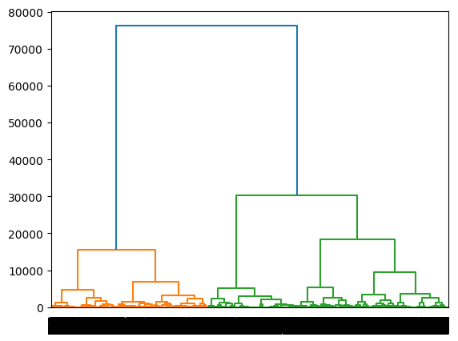

```python
subset_size = 50000  # Adjust the size based on your system's capacity
subset = selected_features.sample(n=subset_size, random_state=42)

# Perform hierarchical clustering and create dendrogram for the subset
subset_dendro = hierarchy.dendrogram(hierarchy.linkage(subset, method='ward'))
```

```
[12412043458.570118, 2584296787.5496607, 1173329391.8772554, 717024209.509017, 495338307.2097812, 399888365.0749663, 316935285.08808684, 263054467.78360373, 222696705.19429564]
```

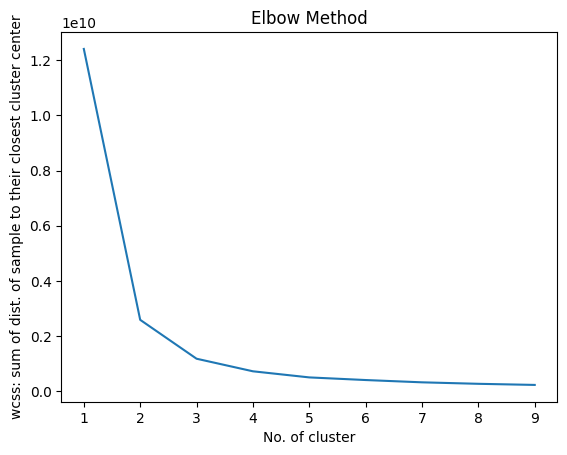

```python
# inertia (elbow method)
from sklearn.cluster import KMeans
wcss=[] #within-cluster sums of squares, calculated by taking the sum of the squared Euclidean distances between each observation and the centroid of its respective cluster.
for i in range(1,10):
    kmeans=KMeans(n_clusters=i,init='k-means++',)
    kmeans.fit(X)
    wcss.append(kmeans.inertia_)
print(wcss)
plt.plot(range(1,10),wcss)
plt.title('Elbow Method')
plt.xlabel('No. of cluster')
plt.ylabel('wcss: sum of dist. of sample to their closest cluster center' )
```

```python
kmeans_1 = KMeans(n_clusters=5)
kmeans_1.fit(X)
cluster_pred=kmeans_1.predict(X)
cluster_labels=kmeans_1.labels_
cluster_center=kmeans_1.cluster_centers_
print(cluster_labels)
```

```
[2 2 0 ... 1 4 1]
```

```python
# datapoint of each centroid
centroids_df = pd.DataFrame(cluster_center, columns=['Habit Forming', 'Therapeutic Class', 'Action Class', 'Side Effects', 'Usage'])
print(centroids_df)
```

```
   Habit Forming  Therapeutic Class  Action Class  Side Effects      Usage
0       0.012511           9.138711     74.303496    655.488692  13.466280
1       0.000022           4.979945     58.892065    103.780088  19.667662
2       0.002285           4.354300     45.654303    810.623981  18.449666
3       0.000202           5.427600     63.222600    456.713274  20.885908
4       0.000253           4.299479     54.980433    289.715495  23.669777
```

```python
# each observations and its nearest centroid
selected_features['centroids'] = cluster_labels
display(selected_features.head(10))
```

|  | Habit Forming | Therapeutic Class | Action Class | Side Effects | Usage | centroids |
| --- | --- | --- | --- | --- | --- | --- |
| 0 | 0 | 1 | 79 | 865 | 17 | 2 |
| 1 | 0 | 1 | 47 | 862 | 17 | 2 |
| 2 | 0 | 13 | 79 | 626 | 19 | 0 |
| 4 | 0 | 13 | 38 | 785 | 14 | 2 |
| 6 | 0 | 1 | 79 | 865 | 17 | 2 |
| 7 | 0 | 1 | 47 | 862 | 17 | 2 |
| 9 | 0 | 13 | 79 | 675 | 20 | 0 |
| 10 | 0 | 5 | 40 | 225 | 23 | 4 |
| 11 | 0 | 13 | 79 | 675 | 20 | 0 |
| 13 | 0 | 1 | 79 | 545 | 36 | 3 |

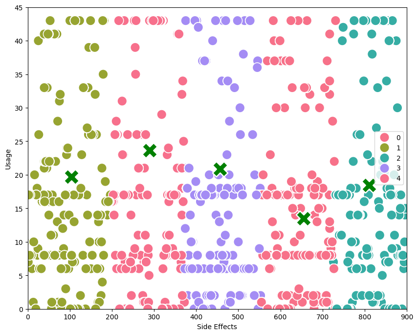

```python
plt.figure(figsize=(10, 8))
bright_palette = sns.color_palette("husl", as_cmap=True)

sns.scatterplot(data=selected_features, x="Side Effects", y="Usage", hue='centroids', s=200, palette = bright_palette)
sns.scatterplot(data=centroids_df, x='Side Effects', y='Usage', marker='X', color='green', s=500)

plt.ylim(0, 45)
plt.xlim(0, 900)

plt.show()
```